# Exploratory Data Analysis of Breweries in United States

Garrett Drake and Eny Ntuk

2022-10-16

## Objective

### This studies is to analyze the ABV (Alcohol By Volume) versus the IBU (International Bitterness Unit) of 2410 US craft beers made by 558 US breweries and to also show any relationship between the ABV and IBU of beers.

```r
# load libraries
library(tidyverse)
```

```r
library(ggplot2)
library(ggthemes)
library(knitr)
library(magrittr)
library(kableExtra)
library(class)
library(caret)
library(e1071)
library(RCurl)
library(stringr)
library(psych)
# load data
beer <- read.csv("https://raw.githubusercontent.com/BivinSadler/MSDS_6306_Doing-Data-Science/Master/Unit%208%20and%209%20Case%20Study%201/Beers.csv", header = T)

breweries <- read.csv("https://raw.githubusercontent.com/BivinSadler/MSDS_6306_Doing-Data-Science/Master/Unit%208%20and%209%20Case%20Study%201/Breweries.csv", header = T)
```

# Problem 1

```r
######## Problem 1 ----- How many breweries are in each state #####
breweries$State <- factor(breweries$State) # put into factor so can count
levels(breweries$State) # check levels
```

```
##  [1] " AK" " AL" " AR" " AZ" " CA" " CO" " CT" " DC" " DE" " FL" " GA" " HI"
## [13] " IA" " ID" " IL" " IN" " KS" " KY" " LA" " MA" " MD" " ME" " MI" " MN"
## [25] " MO" " MS" " MT" " NC" " ND" " NE" " NH" " NJ" " NM" " NV" " NY" " OH"
## [37] " OK" " OR" " PA" " RI" " SC" " SD" " TN" " TX" " UT" " VA" " VT" " WA"
## [49] " WI" " WV" " WY"
```

```r
num_breweries <- breweries %>% count(State) # get total count of breweries by state into new DF
num_breweries <- rename(num_breweries, total_number = n) # rename column to total_number
table(breweries$State)
```

```
##
##  AK  AL  AR  AZ  CA  CO  CT  DC  DE  FL  GA  HI  IA  ID  IL  IN  KS  KY  LA  MA
##   7   3   2  11  39  47   8   1   2  15   7   4   5   5  18  22   3   4   5  23
##  MD  ME  MI  MN  MO  MS  MT  NC  ND  NE  NH  NJ  NM  NV  NY  OH  OK  OR  PA  RI
##   7   9  32  12   9   2   9  19   1   5   3   3   4   2  16  15   6  29  25   5
##  SC  SD  TN  TX  UT  VA  VT  WA  WI  WV  WY
##   4   1   3  28   4  16  10  23  20   1   4
```

# Problem 1 Printout

## With plot of breweries by state in order from least to greatest

```r
kable(num_breweries, caption = "Problem 1 Breweries per state")
```

Problem 1 Breweries per state

| State | total_number |
| --- | --- |
| AK | 7 |
| AL | 3 |
| AR | 2 |
| AZ | 11 |
| CA | 39 |
| CO | 47 |
| CT | 8 |
| DC | 1 |
| DE | 2 |
| FL | 15 |
| GA | 7 |
| HI | 4 |
| IA | 5 |
| ID | 5 |
| IL | 18 |
| IN | 22 |
| KS | 3 |
| KY | 4 |
| LA | 5 |
| MA | 23 |
| MD | 7 |
| ME | 9 |
| MI | 32 |
| MN | 12 |
| MO | 9 |
| MS | 2 |
| MT | 9 |
| NC | 19 |
| ND | 1 |
| NE | 5 |
| NH | 3 |
| NJ | 3 |
| NM | 4 |
| NV | 2 |
| NY | 16 |
| OH | 15 |
| OK | 6 |
| OR | 29 |
| PA | 25 |
| RI | 5 |
| SC | 4 |
| SD | 1 |
| TN | 3 |
| TX | 28 |
| UT | 4 |
| VA | 16 |
| VT | 10 |
| WA | 23 |
| WI | 20 |
| WV | 1 |
| WY | 4 |

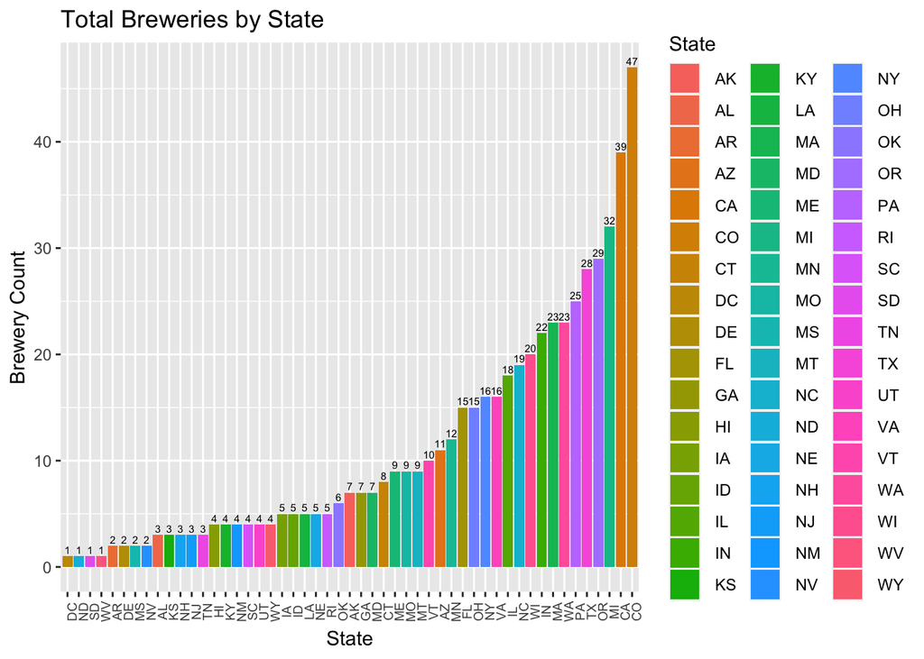

```r
# plot breweries by state in order from least to greatest
num_breweries %>% ggplot(aes(x=reorder(State,total_number), y = total_number)) +
  geom_bar(aes(fill = State), position = "dodge", stat = "identity") +
  geom_text(aes(label=total_number), position=position_dodge(width=0.9), size=2.0, vjust=-0.35) +
  theme(axis.text.x=element_text(size=rel(0.8), angle=90)) +
  ggtitle("Total Breweries by State") +
  labs(x="State",y="Brewery Count")
```

## Problem 2 Merege data sets and provide first and last 6 rows

```r
####### Problem 2 Merge beer data with the breweries data. Print the first 6 observations and the last six observations to check the merged file.  (RMD only, this does not need to be included in the presentation or the deck.) ########
big_beer <- full_join(beer, breweries, by = c("Brewery_id" = "Brew_ID" ))
big_beer <- rename(big_beer, Beer = Name.x, Brewery = Name.y, Beer_Type = Style)
```

### First 6 rows of merged data set

```r
head(big_beer, n =6)
```

```
##                  Beer Beer_ID   ABV IBU Brewery_id
## 1            Pub Beer    1436 0.050  NA        409
## 2         Devil's Cup    2265 0.066  NA        178
## 3 Rise of the Phoenix    2264 0.071  NA        178
## 4            Sinister    2263 0.090  NA        178
## 5       Sex and Candy    2262 0.075  NA        178
## 6        Black Exodus    2261 0.077  NA        178
##                        Beer_Type Ounces                   Brewery City State
## 1            American Pale Lager     12 10 Barrel Brewing Company Bend    OR
## 2        American Pale Ale (APA)     12       18th Street Brewery Gary    IN
## 3                   American IPA     12       18th Street Brewery Gary    IN
## 4 American Double / Imperial IPA     12       18th Street Brewery Gary    IN
## 5                   American IPA     12       18th Street Brewery Gary    IN
## 6                  Oatmeal Stout     12       18th Street Brewery Gary    IN
```

### Last 6 rows of merged data set

```r
tail(big_beer, n = 6)
```

```
##                             Beer Beer_ID   ABV IBU Brewery_id
## 2405 Rocky Mountain Oyster Stout    1035 0.075  NA        425
## 2406                   Belgorado     928 0.067  45        425
## 2407               Rail Yard Ale     807 0.052  NA        425
## 2408             B3K Black Lager     620 0.055  NA        425
## 2409         Silverback Pale Ale     145 0.055  40        425
## 2410        Rail Yard Ale (2009)      84 0.052  NA        425
##                     Beer_Type Ounces                 Brewery   City State
## 2405           American Stout     12 Wynkoop Brewing Company Denver    CO
## 2406              Belgian IPA     12 Wynkoop Brewing Company Denver    CO
## 2407 American Amber / Red Ale     12 Wynkoop Brewing Company Denver    CO
## 2408              Schwarzbier     12 Wynkoop Brewing Company Denver    CO
## 2409  American Pale Ale (APA)     12 Wynkoop Brewing Company Denver    CO
## 2410 American Amber / Red Ale     12 Wynkoop Brewing Company Denver    CO
```

## Problem 3 Address missing values

### There are 62 missing values in ABV and 1005 in IBU

```r
######### Problem 3 - address missing values ######
colSums(is.na(breweries)) # no missing values in the breweries data set
```

```
## Brew_ID    Name    City   State
##       0       0       0       0
```

```r
colSums(is.na(beer)) # ABV has 62 missing values, IBU has 1005 missing values
```

```
##       Name    Beer_ID        ABV        IBU Brewery_id      Style     Ounces
##          0          0         62       1005          0          0          0
```

```r
colSums(is.na(big_beer)) # sanity check for merged data ABV has 62 missing values, IBU has 1005 missing values
```

```
##       Beer    Beer_ID        ABV        IBU Brewery_id  Beer_Type     Ounces
##          0          0         62       1005          0          0          0
##    Brewery       City      State
##          0          0          0
```

```r
# Used kable Extra library to make document more presentable
colSums(is.na(big_beer)) %>%
  kable("html", caption = "Problem 3 Missing Values in Each Variable") %>%
  kable_styling()
```

Problem 3 Missing Values in Each Variable

|  | x |
| --- | --- |
| Beer | 0 |
| Beer_ID | 0 |
| ABV | 62 |
| IBU | 1005 |
| Brewery_id | 0 |
| Beer_Type | 0 |
| Ounces | 0 |
| Brewery | 0 |
| City | 0 |
| State | 0 |

## Problem 4

```r
######### Problem 4 Compute median ABV and IBU for each state. Plot a bar chart to compare. ########
state_med_ABV_IBU <- big_beer %>% group_by(State) %>% summarise(Median_ABV = median(ABV, na.rm = TRUE), Median_IBU = median(IBU, na.rm = TRUE)) # create data set with medians ABV and IBU for each state
```

### Table of Median ABV and IBU by State

```r
kable(state_med_ABV_IBU, caption = "Table of Median ABV and IBU by State")
```

Table of Median ABV and IBU by State

| State | Median_ABV | Median_IBU |
| --- | --- | --- |
| AK | 0.0560 | 46.0 |
| AL | 0.0600 | 43.0 |
| AR | 0.0520 | 39.0 |
| AZ | 0.0550 | 20.5 |
| CA | 0.0580 | 42.0 |
| CO | 0.0605 | 40.0 |
| CT | 0.0600 | 29.0 |
| DC | 0.0625 | 47.5 |
| DE | 0.0550 | 52.0 |
| FL | 0.0570 | 55.0 |
| GA | 0.0550 | 55.0 |
| HI | 0.0540 | 22.5 |
| IA | 0.0555 | 26.0 |
| ID | 0.0565 | 39.0 |
| IL | 0.0580 | 30.0 |
| IN | 0.0580 | 33.0 |
| KS | 0.0500 | 20.0 |
| KY | 0.0625 | 31.5 |
| LA | 0.0520 | 31.5 |
| MA | 0.0540 | 35.0 |
| MD | 0.0580 | 29.0 |
| ME | 0.0510 | 61.0 |
| MI | 0.0620 | 35.0 |
| MN | 0.0560 | 44.5 |
| MO | 0.0520 | 24.0 |
| MS | 0.0580 | 45.0 |
| MT | 0.0550 | 40.0 |
| NC | 0.0570 | 33.5 |
| ND | 0.0500 | 32.0 |
| NE | 0.0560 | 35.0 |
| NH | 0.0550 | 48.5 |
| NJ | 0.0460 | 34.5 |
| NM | 0.0620 | 51.0 |
| NV | 0.0600 | 41.0 |
| NY | 0.0550 | 47.0 |
| OH | 0.0580 | 40.0 |
| OK | 0.0600 | 35.0 |
| OR | 0.0560 | 40.0 |
| PA | 0.0570 | 30.0 |
| RI | 0.0550 | 24.0 |
| SC | 0.0550 | 30.0 |
| SD | 0.0600 | NA |
| TN | 0.0570 | 37.0 |
| TX | 0.0550 | 33.0 |
| UT | 0.0400 | 34.0 |
| VA | 0.0565 | 42.0 |
| VT | 0.0550 | 30.0 |
| WA | 0.0555 | 38.0 |
| WI | 0.0520 | 19.0 |
| WV | 0.0620 | 57.5 |
| WY | 0.0500 | 21.0 |

### Barchart of Median ABV by State ordered from least to greatest

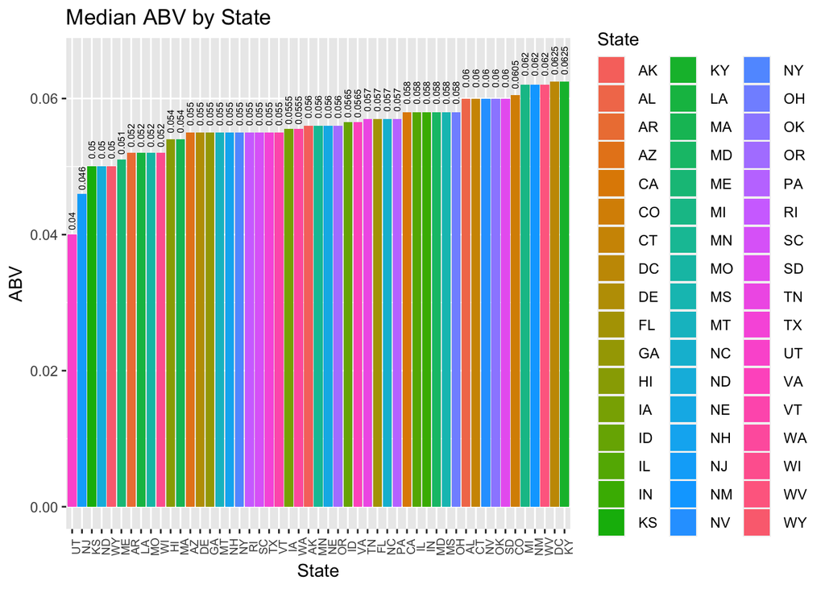

```r
# create bar chart for median ABV by state with color and ordered from least to greatest
state_med_ABV_IBU %>% ggplot(aes(x=reorder(State,Median_ABV), y = Median_ABV)) +
  geom_bar(aes(fill = State), stat = "identity") +
  geom_text(aes(label=Median_ABV), position=position_stack(vjust = 1.05), size=2.0, angle = 90) +
  theme(axis.text.x=element_text(size=rel(0.8), angle=90)) +
  ggtitle("Median ABV by State") +
  labs(x="State",y="ABV")
```

### Barchart of Median IBU by State ordered from least to greatest

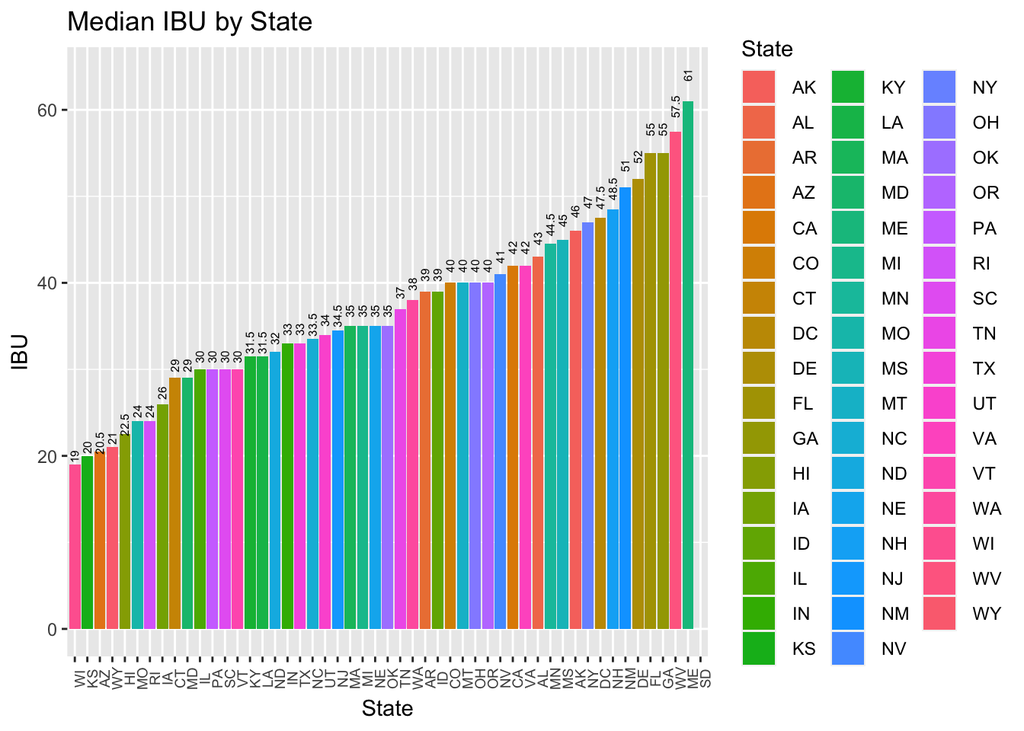

```r
#create bar chart for median IBU by state with more color order by least to greatest
state_med_ABV_IBU %>% ggplot(aes(x=reorder(State,Median_IBU), y = Median_IBU)) +
  geom_bar(aes(fill = State), stat = "identity") +
  geom_text(aes(label=Median_IBU), position=position_stack(vjust = 1.05), size=2.0, angle = 90) +
  theme(axis.text.x=element_text(size=rel(0.8), angle=90)) +
  ggtitle("Median IBU by State") +
  labs(x="State",y="IBU")
```

## Problem 5

Colorado has the maximum ABV beer named “Lee Hill Series Vol. 5 - Belgian Style Quadrupel Ale” with an ABV of .128

Oregon has the maximum IBU beer named “Bitter Bitch Imperial IPA” with an IBU of 138

```r
########### Problem 5 Which state has the maximum alcoholic (ABV) beer? Which state has the most bitter (IBU) beer? ##########
which.max(big_beer$ABV) # gives number of which state has max ABV, which is number 2279
```

```
## [1] 2279
```

```r
big_beer$State[2279] # 2279 is CO, so Colorado has max ABV
```

```
## [1]  CO
## 51 Levels:  AK  AL  AR  AZ  CA  CO  CT  DC  DE  FL  GA  HI  IA  ID  IL ...  WY
```

```r
max(big_beer$ABV, na.rm = T) # highest ABV is .128
```

```
## [1] 0.128
```

```r
big_beer$Beer[2279] # Name of highest ABV Beer is "Lee Hill Series Vol. 5 - Belgian Style Quadrupel Ale"
```

```
## [1] "Lee Hill Series Vol. 5 - Belgian Style Quadrupel Ale"
```

```r
big_beer$ABV[2279] # sanity check, all lings up
```

```
## [1] 0.128
```

```r
which.max(big_beer$IBU) # gives number of which state has max IBU, which is number 148
```

```
## [1] 148
```

```r
big_beer$State[148] # 148 is OR, so Oregon has max IBU
```

```
## [1]  OR
## 51 Levels:  AK  AL  AR  AZ  CA  CO  CT  DC  DE  FL  GA  HI  IA  ID  IL ...  WY
```

```r
max(big_beer$IBU, na.rm = T) # highest IBU is 138
```

```
## [1] 138
```

```r
big_beer$Beer[148] # Name of highest IBU is "Bitter Bitch Imperial IPA"
```

```
## [1] "Bitter Bitch Imperial IPA"
```

```r
big_beer$IBU[148] # sanity check, all lings up
```

```
## [1] 138
```

## Problem 6

Summary Statistics

The minimum ABV is .001 and maximum is .128  
The median ABV is .056  
The mean ABV is .0598, standard deviation is .014, and there were 62 missing values  
50% of the distribution of beer ABV is between .05 and .067

```r
######## Problem 6. Comment on the summary statistics and distribution of the ABV variable. #########
summary(big_beer$ABV) # get summary statistics
```

```
##    Min. 1st Qu.  Median    Mean 3rd Qu.    Max.    NA's
## 0.00100 0.05000 0.05600 0.05977 0.06700 0.12800      62
```

```r
sd(big_beer$ABV, na.rm = TRUE) # get SD of ABV
```

```
## [1] 0.01354173
```

## Boxplot of beer ABV

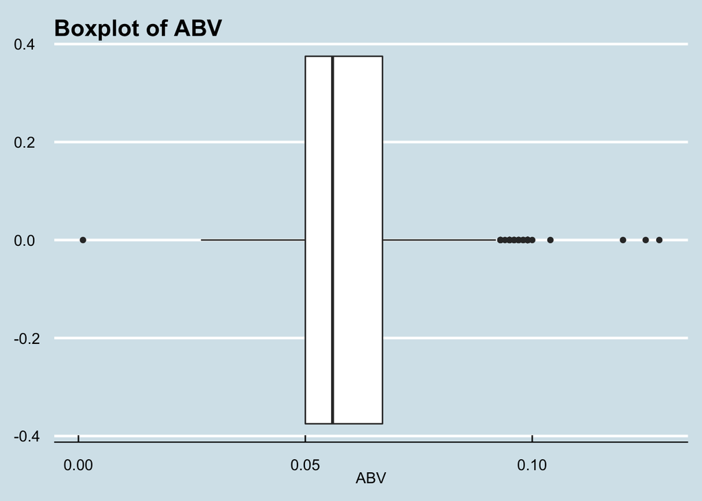

```r
#box plot of beers
big_beer %>% ggplot(aes(x=ABV)) +
  geom_boxplot() +
  theme_economist() +
  scale_color_economist() +
  ggtitle("Boxplot of ABV")
```

## Histogram of beer ABV

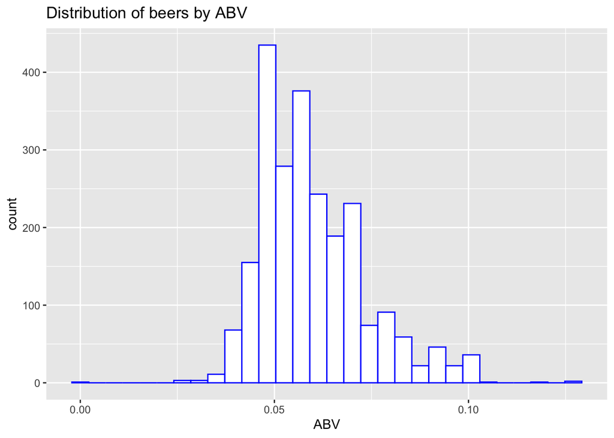

```r
# Histogram of beers
big_beer %>% ggplot(aes(x=ABV)) +
  geom_histogram( colour="blue", fill="white") +
  ggtitle("Distribution of beers by ABV")
```

## Problem 7

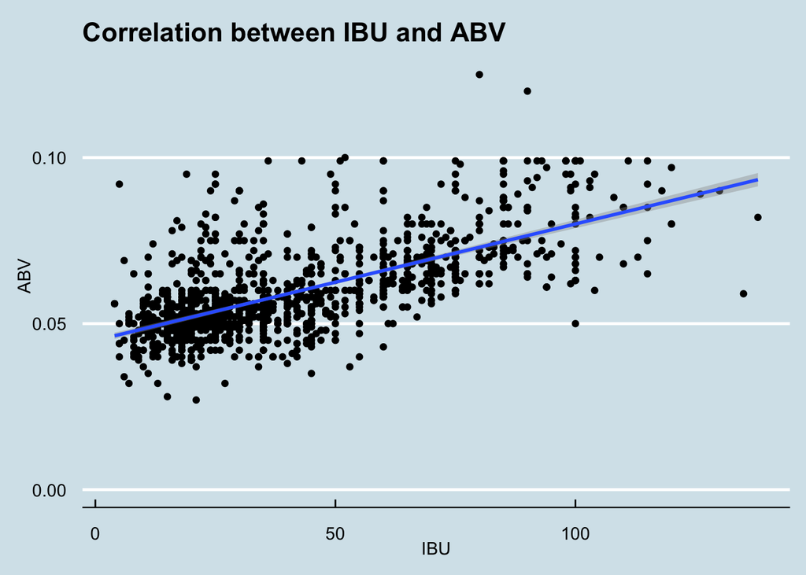

```r
################ Problem 7. Is there an apparent relationship between the bitterness of the beer and its alcoholic content? Draw a scatter plot.  Make your best judgment of a relationship and EXPLAIN your answer. #########

big_beer %>% ggplot(aes(x = IBU, y = ABV)) +
  geom_point() +
  geom_smooth(method=lm) + # add linear regression line
  theme_economist() +
  scale_color_economist()+
  theme(axis.text.x=element_text(size=rel(1.0)))+
  ggtitle("Correlation between IBU and ABV ") +
  labs(x="IBU",y="ABV")
```

### There is evidence to suggest that a medium positive relationship between IBU and ABV exists,i.e. generally as IBU increases so does ABV and vice versa. A linear estimate of this relationship is shown by the blue line. Correlation coefficient r = .671, representing medium correlation

```r
cor(big_beer$IBU, big_beer$ABV, use = 'pairwise.complete.obs', method = "pearson")
```

```
## [1] 0.6706215
```

# Problem 8

## Build Hypertuned Knn model

```r
beerKnn <- na.omit(big_beer) %>% select(ABV, IBU, Beer_Type) %>%  filter(grepl("IPA|Ale", Beer_Type, ignore.case = TRUE)) # create data frame to do Knn test with ABV, IBU and Beer types (IPA or Ale)

beerKnn$ipa_ale <- factor(ifelse(grepl("IPA", beerKnn$Beer_Type, ignore.case = TRUE), "IPA", "Ale"))
# Build Hypertuned model to find best K
set.seed(317)
iterations <-  100 # 200 iterations takes like 1.5 mins to run, consider smaller, tried 60 and much faster with minimal change in results
numks <-  60 # gives back 60 iterations of k values
splitPerc <-  .75 # 75 percent split
masterAcc <-  matrix(nrow = iterations, ncol = numks)
for(j in 1:iterations)
{
  trainIndices = sample(1:dim(beerKnn)[1],round(splitPerc * dim(beerKnn)[1]))
  train <-  beerKnn[trainIndices , ]
  test <-  beerKnn[-trainIndices , ]
  for(i in 1:numks)
  {
    classifications = knn(train[,c("ABV", "IBU")],test[,c("ABV", "IBU")],train$ipa_ale, prob = TRUE, k = i)
    table(classifications,test$ipa_ale)
    CM = confusionMatrix(table(classifications,test$ipa_ale))
    masterAcc[j,i] = CM$overall[1]
  }

}
MeanAcc <- colMeans(masterAcc)
which.max(MeanAcc) # which K gives max percentage
```

```
## [1] 5
```

```r
max(MeanAcc)
```

```
## [1] 0.8607884
```

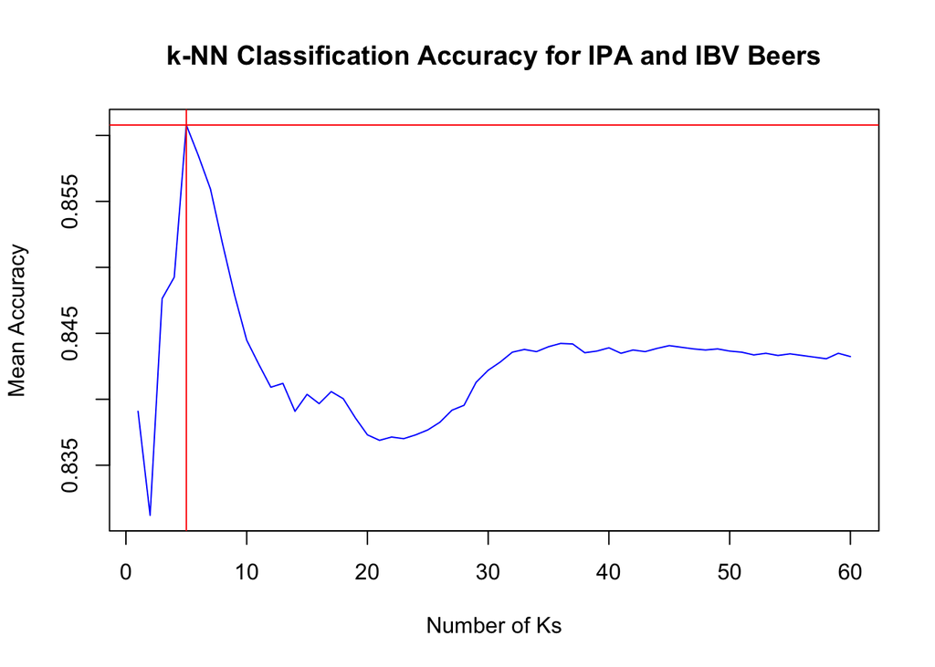

```r
plot(seq(1,numks,1),MeanAcc, type = "l", xlab = "Number of Ks", ylab = "Mean Accuracy", main = "k-NN Classification Accuracy for IPA and IBV Beers", col = "blue")
abline(v = 5, col = "red")
abline(h = .8607884, col = "red")
```

# Addition things

T test for ABV and IBU

```r
t.test(ABV ~ ipa_ale, data = beerKnn)
```

```
##
##  Welch Two Sample t-test
##
## data:  ABV by ipa_ale
## t = -16.521, df = 788.39, p-value < 2.2e-16
## alternative hypothesis: true difference in means between group Ale and group IPA is not equal to 0
## 95 percent confidence interval:
##  -0.01422526 -0.01120381
## sample estimates:
## mean in group Ale mean in group IPA
##        0.05642832        0.06914286
```

```r
t.test(IBU ~ ipa_ale, data = beerKnn)
```

```
##
##  Welch Two Sample t-test
##
## data:  IBU by ipa_ale
## t = -30.3, df = 797.38, p-value < 2.2e-16
## alternative hypothesis: true difference in means between group Ale and group IPA is not equal to 0
## 95 percent confidence interval:
##  -40.13941 -35.25505
## sample estimates:
## mean in group Ale mean in group IPA
##          34.25175          71.94898
```